# Aside

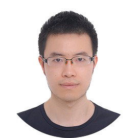

## Contact

- biozhangjn@gmail.com
- Jiannan_scu
- [github.com/biozhangjn](https://www.github.com/biozhangjn/)
- [www.zhangjn.xyz](https://www.zhangjn.xyz/)
- qq124975496

For more information, please contact me via email.

## Skills

Wet-lab

- Molecular cloning
- Functional analysis
- IHC/ISH/FISH/Co-IP/Chip-Seq…
- CRISPR/Cas9
- PGCs culture and Microinjection

Dry-lab

- RNA-Seq data analysis
- scRNA-Seq data analysis
- Highly skilled in R and Bash.

## Disclaimer

Made with the R package [**pagedown**](https://github.com/rstudio/pagedown).

Last updated on 2024-09-01.

# Main

## Jiannan Zhang (张剑南)

I am **Jiannan Zhang (张剑南)**, a scientific researcher and currently work as an Associate Professor in the College of Life Sciences at **Sichuan University**. I conduct my research as a member of Professor Yajun Wang’s lab.

My research interests are centered around **Avian Physiology**, **Endocrinology and Metabolism**, with a focus on understanding the mechanisms that regulate growth, development, and reproduction in chickens. I am particularly interested in exploring the role of hormones in modulating these processes and have conducted studies on the hormonal regulation of feed intake, nutrient utilization, and energy metabolism.

In addition to my work in avian physiology, I am also engage in the study of **Genome Editing** in chickens. I aim to develop new tools and technologies to improve the efficiency and precision of genetic modifications in avian species. My ultimate goal is to contribute to a better understanding of avian biology and to develop innovative solutions for improving poultry production and welfare.

## Research Experience

### Associate Professor

Sichuan University

Sichuan University

present - 2023

- 2023-present, Associate Professor, The College of Life Sciences

### Post-doctoral Fellow

Sichuan University

Sichuan University

2023 - 2017

### Associate Research Fellow

Sichuan University

Sichuan University

2022 - 2021

### Assistant Research Fellow

Sichuan University

Sichuan University

2021 - 2017

- 2017-2021, Assistant Research Fellow, The College of Life Sciences

## Education

### PhD., Cell Biology

Sichuan University

Sichuan, CN

2017 - 2011

### B.S., National Base of Life Science & Biotechnology Education

Sichuan University

Sichuan, CN

2011 - 2007

## Teaching Experience

### Developmental biology (发育生物学)

*Undergraduate level class, The College of Life Sciences*

Sichuan University

2024 - 2019

- Undergraduate level class

### Cell biology (细胞生物学)

*Undergraduate level class, The College of Life Sciences*

Sichuan University

2021

- Undergraduate level class

## Grants

### 热应激影响家鸡肝脏脂质代谢的调控机制解析(2023NSFSC0230 )

**主持**, CNY ￥200,000, 四川省自然科学基金

N/A

2024 - 2023

### 垂体激素ACTH调控家鸡肝脏糖脂代谢的机制探究 (2020T130439)

**主持**, CNY ￥180,000, 中国博士后科学基金特别资助

N/A

2021 - 2020

### 多不饱和脂肪酸调控家鸡肝脏脂肪生成的机制解析（省重） (2019YJ0017)

**主持**, CNY ￥100,000, 四川省科学技术厅-应用基础研究

N/A

2021 - 2019

### 家鸡GPR120受体介导多不饱和脂肪酸对肝脏脂质代谢的调节效应探究 (31802056)

**主持**, CNY ￥300,000, 国家自然科学基金青年项目

N/A

## Publications

### Genome-wide mapping of the binding sites of myocyte enhancer factor 2A in chicken primary myoblasts

**Poultry Science**. 2024. doi: 10.1016/j.psj.2024.104097

N/A

2024

- Xinglong Wang<sup>#</sup>, **Jiannan Zhang**<sup>#</sup>, Jiancheng Su, Tianjiao Huang, Ling Lian, Qinghua Nie, Xin Zhang, Juan Li, Yajun Wang*

### Functional Analysis and Tissue-Specific Expression of Calcitonin and CGRP with RAMP-Modulated Receptors CTR and CLR in Chickens

**animals**. 2024. doi: 10.3390/ani14071058

N/A

- Tianjiao Huang, Jiancheng Su, Xinglong Wang, Ningkun Shi, Xiao Zhang, Jiliang He, Juan Li, **Jiannan Zhang*** and Yajun Wang*

### Cholecystokinin (CCK) and its receptors (CCK1R and CCK2R) in chickens: functional analysis and tissue expression

**Poultry Science**. 2023, 102 (1), 102273. [doi: 10.1016/j.psj.2022.102273](https://doi.org/10.1016/j.psj.2022.102273)

N/A

2023

- Yiping, Wan; Qiuyang, Deng; Zhichun, Zhou; Yue, Deng; **Jiannan, Zhang**; Juan, Li;Yajun, Wang*;

### A gene expression atlas of Lohmann white chickens

**bioRxiv**. 2022. doi: 10.1101/2022.07.30.500160

N/A

2022

- **Jiannan Zhang**<sup>#</sup>, Xinglong Wang, Can Lv, Yiping Wan, Xiao Zhang, Juan Li, Yajun Wang*
- preprint

### Characterization of the Chicken Melanocortin 5 Receptor and its Potential Role in Regulating Hepatic Glucolipid Metabolism

**Frontiers in physiology**. 2022, 2101. [doi: 10.3389/fphys.2022.917712](https://doi.org/10.3389/fphys.2022.917712)

N/A

- Xiao Zhang<sup>#</sup>, Jiancheng Su<sup>#</sup>, Tianjiao Huang, Xinglong Wang, Chenlei Wu, Jing Li, Juan LI, **Zhang, Jiannan***, Yajun Wang*

### Characterization of CRH-Binding Protein (CRHBP) in chickens: molecular cloning, tissue distribution and investigation of its role as a negative feedback regulator within the hypothalamus–pituitary–adrenal axis

**Genes**. 2022, 13(10), 1680. [doi: 10.3390/genes13101680](https://doi.org/10.3390/genes13101680)

N/A

- Yiping Wan, Zheng Zhang, Dongliang Lin, Xinglong Wang, Tianjiao Huang, Jiancheng Su, **Jiannan Zhang**, Juan Li, Yajun Wang*

### Characterization of Chicken Α2A-Adrenoceptor: Molecular Cloning, Functional Analysis, and Its Involvement in Ovarian Follicular Development.

N/A

- Jiang, B.<sup>#</sup>; Cao, B.; Zhou, Z.; Li, Z.; Lv, C.; **Zhang, J.**; Zhang, H.; Wang, Y.; Li, J.*;

### Evidence for Neuropeptide W Acting as a Physiological Corticotropin-Releasing Inhibitory Factor in Male Chickens

N/A

- Liu, M.<sup>#</sup>; Bu, G.<sup>#</sup>; Wan, Y.; **Zhang, J.**; Mo, C.; Li, J.; Wang, Y.*;

### LncEDCH1 improves mitochondrial function to reduce muscle atrophy by interacting with SERCA2

N/A

- Cai, B.<sup>#</sup>; Ma, M.<sup>#</sup>; Zhang, J.; Wang, Z.; Kong, S.; Zhou, Z.; Lian, L.; **Zhang, J.**; Li, J.; Wang, Y.; Li, H.*; Zhang, X.; Nie, Q.*;
- Impact Factor = 10.18

### Neuropeptide S (NPS) and its receptor (NPSR1) in chickens: cloning, tissue expression, and functional analysis

**Poultry Science**. 2021, 100 (12), 101445. [doi: 10.1016/j.psj.2021.101445](https://doi.org/10.1016/j.psj.2021.101445)

N/A

2021

- Chao Fang<sup>#</sup>, **Jiannan Zhang<sup>#</sup>**, Yiping Wan, Zejiao Li, Feiyang Qi, Yuanhao Dang, Juan Li, Yajun Wang*;

### Molecular Cloning and Functional Characterization of Three 5-HT Receptor Genes (HTR1B, HTR1E, and HTR1F) in Chickens

**Genes**. 2021, 12(6): 891. [doi: 10.3390/genes12060891](https://doi.org/10.3390/genes12060891)

N/A

- Caiyun Sun, Yang Qiu, Qin Ren, Xiao Zhang, Baolong Cao, Yi Zou, Juan Li, **Jiannan Zhang***, Yajun Wang;

### Single-Cell RNA Sequencing Analysis of Chicken Anterior Pituitary: A Bird’s-Eye View on Vertebrate Pituitary

**Frontiers in physiology**. 2021, 12. [doi: 10.3389/fphys.2021.562817](https://doi.org/10.3389/fphys.2021.562817)

N/A

- **Jiannan Zhang<sup>#</sup>**, Can Lv<sup>#</sup>, Chunheng Mo, Meng Liu, Yiping Wan, Juan Li*, Yajun Wang*;
- Impact Factor = 4.566

### Characterization of Four Orphan Receptors (GPR3, GPR6, GPR12 and GPR12L) in Chickens and Ducks and Regulation of GPR12 Expression in Ovarian Granulosa Cells by Progesterone

**Genes**. 2021, 12(4): 489. [doi: 10.3390/genes12040489](https://doi.org/10.3390/genes12040489)

N/A

- Li, Z.; Jiang, B.; Cao, B.; Zhang, Z.; **Zhang, J.**; Li, J.; Huang, Y.*; Wang, Y.*;

### Characterization of four urotensin II receptors (UTS2Rs) in chickens

**Peptides**. 2021, 138: 170482. [doi: 10.1016/j.peptides.2020.170482](https://doi.org/10.1016/j.peptides.2020.170482)

N/A

- Cui, L.<sup>#</sup>, Lv, C.<sup>#</sup>, **Zhang, J.**, Li, J.*, & Wang, Y.*;

### The Asp298Asn polymorphism of melanocortin‐4 receptor (MC4R) in pigs: evidence for its potential effects on MC4R constitutive activity and cell surface expression

**Animal Genetics**. 2020, 51(5):694-706. [doi: 10.1111/age.12986](https://onlinelibrary.wiley.com/doi/full/10.1111/age.12986)

N/A

2020

- **Zhang, J<sup>#</sup>**; Li, J<sup>#</sup>; Wu, C; Hu, Z; An, L; Wan, Y; Fang, C; Zhang, X; Li, J*; Wang, Y*;
- Impact Factor = 2.841

### Melanocortin Receptor 4 (MC4R) Signaling System in Nile Tilapia

**International Journal of Molecular Sciences**. 2020, 21(19):7036. [doi: 10.3390/ijms21197036](https://doi.org/10.3390/ijms21197036)

N/A

- Liu, Tianqiang; Deng, Yue; Zhang, Zheng; Cao, Baolong; Li, Jing; Sun, Caiyun; Hu, Zhixing; **Zhang, Jiannan***; Li, Juan; Wang, Yajun*;
- Impact Factor = 4.556

### Characterization of a novel thyrotropin-releasing hormone receptor, TRHR3, in chickens

**Poultry Science**. 2020, 99(3):1643-1654. [doi: 10.1016/j.psj.2019.10.062](https://www.sciencedirect.com/science/article/pii/S0032579119528267)

N/A

- Li, Xiaoxiao<sup>#</sup>; Li, Zhengyang<sup>#</sup>; Deng, Yue; **Zhang, Jiannan**; Li, Juan*; Wang, Yajun*;

### Characterization of the neuropeptide FF (NPFF) gene in chickens: evidence for a single bioactive NPAF peptide encoded by the NPFF gene in birds

**Domestic Animal Endocrinology**. 2020, :106435. [doi: 10.1016/j.domaniend.2020.106435](https://www.sciencedirect.com/science/article/pii/S0739724020300023)

N/A

- Chen, J<sup>#</sup>; Huang, S<sup>#</sup>; **Zhang, J**; Li, J*; Wang, Y*;

### Arginine vasotocin (AVT)/mesotocin (MT) receptors in chickens: Evidence for the possible involvement of AVT-AVPR1 signaling in the regulation of oviposition and pituitary prolactin expression

**General and Comparative Endocrinology**. 2019, 281:91-104. [doi: 10.1016/j.ygcen.2019.05.013](https://www.sciencedirect.com/science/article/pii/S0016648019300449)

N/A

2019

- Wu, Chao; Lv, Can; Wan, Yiping; Li, Xiaoxiao; **Zhang, Jiannan***; Li, Juan; Wang, Yajun*;

### Regulation of Pituitary Cocaine-and Amphetamine-Regulated Transcript Expression and Secretion by Hypothalamic Gonadotropin-Releasing Hormone in Chickens

**Frontiers in physiology**. 2019, 10:. [doi: 10.3389/fphys.2019.00882](https://www.ncbi.nlm.nih.gov/pmc/articles/PMC6672714/)

N/A

- Mo, Chunheng; Lv, Can; Huang, Long; Li, Zhengyang; **Zhang, Jiannan**; Li, Juan*; Wang, Yajun*;

### Endothelins (EDN1, EDN2, EDN3) and their receptors (EDNRA, EDNRB, EDNRB2) in chickens: Functional analysis and tissue distribution

**General and comparative endocrinology**. 2019, 283:113231. [doi: 10.1016/j.ygcen.2019.113231](https://www.sciencedirect.com/science/article/pii/S0016648019300164)

N/A

- Liu, Haikun; Luo, Qin; **Zhang, Jiannan**; Mo, Chunheng; Wang, Yajun*; Li, Juan*;

### Identification of a Novel Functional Corticotropin-Releasing Hormone (CRH2) in Chickens and Its Roles in Stimulating Pituitary TSHβ Expression and ACTH Secretion

**Frontiers in Endocrinology**. 2019, 10:595. [doi: 10.3389/fendo.2019.00595](https://www.frontiersin.org/articles/10.3389/fendo.2019.00595/abstract)

N/A

- Bu, Guixian<sup>#</sup>; Fan, Jie<sup>#</sup>; Yang, Ming; Lv, Can; Lin, Yin; Li, Jinxuan; Meng, Fengyan; Du, Xiaogang; Zeng, Xianyin*; **Zhang, Jiannan**; Juan Li; Yajun Wang*

### Characterization of the Apelin/Elabela Receptors (APLNR) in Chickens, Turtles, and Zebrafish: Identification of a Novel Apelin-Specific Receptor in Teleosts

**Frontiers in endocrinology**. 2018, 9:756. [doi: 10.3389/fendo.2018.00756](https://www.frontiersin.org/articles/10.3389/fendo.2018.00756/full)

N/A

2018

- **Zhang, Jiannan**; Zhou, Yawei; Wu, Chenlei; Wan, Yiping; Fang, Chao; Li, Jing; Fang, Wenqian; Yi, Ran; Zhu, Guoqiang; Li, Juan*; Yajun Wang*

### The orphan G protein-coupled receptor 25 (GPR25) is activated by Apelin and Apela in non-mammalian vertebrates

**Biochemical and Biophysical Research Communications**. 2018, 501(2):408-414. [doi: 10.1016/j.bbrc.2018.04.229](https://www.sciencedirect.com/science/article/pii/S0006291X18310271)

N/A

- **Zhang, Jiannan<sup>#</sup>**; Wan, Yiping<sup>#</sup>; Fang, Chao; Chen, Junan; Ouyang, Wangan; Li, Juan*; Wang, Yajun*;

### Characterization of neuromedin U (NMU), neuromedin S (NMS) and their receptors (NMUR1, NMUR2) in chickens

**Peptides**. 2018, 101:69-81. [doi: 10.1016/j.peptides.2017.12.022](https://www.sciencedirect.com/science/article/pii/S0196978117303972)

N/A

- Wan, Yiping<sup>#</sup>; **Zhang, Jiannan<sup>#</sup>**; Fang, Chao; Chen, Junan; Li, Jing; Li, Juan*; Wu, Chenlei; Wang, Yajun*;

### The interaction of MC3R and MC4R with MRAP2, ACTH, α-MSH and AgRP in chickens

**Journal of Endocrinology**. 2017, 234(2):155-174. [doi: 10.1530/JOE-17-0131](https://joe.bioscientifica.com/view/journals/joe/234/2/JOE-17-0131.xml)

N/A

2017

- **Zhang, Jiannan**; Li, Xin; Zhou, Yawei; Cui, Lin; Li, Jing; Wu, Chenlei; Wan, Yiping; Li, Juan*; Wang, Yajun*;
- Impact Factor = 4.706

### Molecular characterization of neuropeptide Y (NPY) receptors (Y1, Y4 and Y6) and investigation of the tissue expression of their ligands (NPY, PYY and PP) in chickens

**General and comparative endocrinology**. 2017, 240:46-60. [doi: 10.1016/j.ygcen.2016.09.005](https://www.sciencedirect.com/science/article/pii/S0016648016302714)

N/A

- Gao, Shunyu<sup>#</sup>; **Zhang, Jiannan<sup>#</sup>**; He, Chen; Meng, Fengyan; Bu, Guixian; Zhu, Guoqiang; Li, Juan*; Wang, Yajun*;

### Characterization of melanin-concentrating hormone (MCH) and its receptor in chickens: Tissue expression, functional analysis, and fasting-induced up-regulation of hypothalamic MCH expression

**Gene**. 2017, 615:57-67. [doi: 10.1016/j.gene.2017.03.009](https://www.sciencedirect.com/science/article/pii/S0378111917301440)

N/A

- Cui, Lin; Lv, Can; **Zhang, Jiannan**; Mo, Chunheng; Lin, Dongliang; Li, Juan*; Wang, Yajun*;

### Molecular characterization of three NPY receptors (Y2, Y5 and Y7) in chickens: Gene structure, tissue expression, promoter identification, and functional analysis

**General and Comparative Endocrinology**. 2016, 236:24-34. [doi: 10.1016/j.ygcen.2016.04.019](https://www.sciencedirect.com/science/article/pii/S0016648016300946)

N/A

2016

- He, Chen<sup>#</sup>; **Zhang, Jiannan<sup>#</sup>**; Gao, Shunyu; Meng, Fengyan; Bu, Guixian; Li, Juan*; Wang, Yajun*;

### Identification and characterization of the free fatty acid receptor 2 (FFA2) and a novel functional FFA2-like receptor (FFA2L) for short-chain fatty acids in pigs: Evidence for the existence of a duplicated FFA2 gene (FFA2L) in some mammalian species

**Domestic animal endocrinology**. 2014, 47:108-118. e1. [doi: 10.1016/j.domaniend.2013.10.004](https://www.sciencedirect.com/science/article/pii/S0739724013001343)

N/A

2014

- **Zhang, J**; Cheng, S; Wang, Y*; Yu, X; Li, J*;

### Synthesis and biological evaluation of novel benzamide derivatives as potent smoothened antagonists

**Bioorganic & medicinal chemistry letters**. 2014, 24(5):1426-1431. [doi: 10.1016/j.bmcl.2014.01.006](https://www.sciencedirect.com/science/article/pii/S0960894X14000250)

N/A

- Wu, Tian-Ming; Wang, Dao-Cai; Xiang, Pu; **Zhang, Jian-Nan**; Sang, Ya-Xiong; Lin, Hong-Jun; Chen, Jie; Xie, Gang; Song, Hang; Zhao, Ying-Lan*;

### Glucagon-like peptide (GCGL) is a novel potential TSH-releasing factor (TRF) in Chickens: I) Evidence for its potent and specific action on stimulating TSH mRNA expression and secretion in the pituitary

**Endocrinology**. 2014, 155(11):4568-4580. [doi: 10.1210/en.2014-1331](https://academic.oup.com/endo/article-abstract/155/11/4568/2422875)

N/A

- Huang, Guian; He, Chen; Meng, Fengyan; Li, Juan; **Zhang, Jiannan**; Wang, Yajun*;

## Conference presentations

### **黑皮质素系统在家鸡能量平衡中的作用机理解析**

四川省细胞生物学会2017年度学术大会

Chengdu, CN

2017

### **家鸡促甲状腺激素受体(cTSHR)的克隆、剪切变体鉴定及其功能分析**

第十六次全国动物遗传育种学术讨论会系列学术报告会

Yangzhou, CN

2011